# RNA-seq data analysis-hands-on session

In this session we will analyze a RNA-seq data set from whole blood of pigs selected for high residue feed intake (RFI) and muscularlly injected with LPS.This data set was part of the data published recently (Liu et al., 2019) in [BMC Genomics](https://bmcgenomics.biomedcentral.com/articles/10.1186/s12864-019-6127-x). For more details about the experimental design, RNA preparation, RNA-seq and data preprocessing, Please see below.

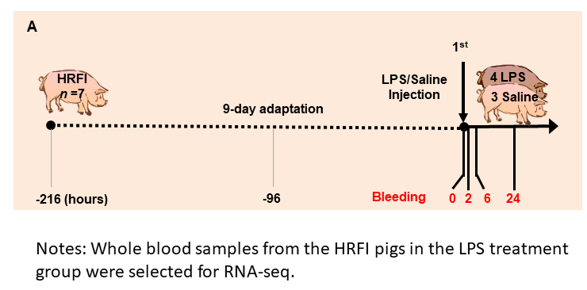

## Introduction to RNA-seq data generation

### Animals, Experimental design and sample collection

The pigs were from Generation 8 of the Yorkshire pig lines selected for high RFI at ISU. Figure 1 shows the experimental design. A total of 7 gilts with an initial body weight (BW) of [59,67] kg from the high-RFI lines were randomly selected. Pigs were housed in randomly assigned individual metabolism crates, had ad libitum access to water, and were fed a corn-soy-based diet twice daily (8:00 am and 5:00 pm), with feed restriction (1.5 kg/day), as previously described. After a 9-day adaptation period, pigs within each line were randomly assigned to either a control (n = 3) or LPS treatment (n = 4) group. Pigs in the treatment group were then challenged with LPS using an established method via intramuscular injection of 30 ug/kg BW of LPS from E. coli O55:B5 (Sigma-Aldrich, St. Louis, MO, USA) dissolved in a endotoxin-free, sterile saline solution at baseline, 0 h post injection (hpi). Pigs in the control group were injected with an equivalent volume of endotoxin-free, sterile saline solution at the equivalent time. At 0, 2, 6, and 24 hpi, blood samples were collected from the jugular vein into Tempus Blood RNA tubes (Life Technologies, Grand Island, NY, USA) for long-term storage at -80 C, Injection and blood collection followed the same order which was the predefined order of metabolism crates in the pen rooms.

### RNA preparation

Total RNA was extracted from the Tempus tube samples of the treatment groups by using preserved blood RNA purification kit I (Norgen Biotek Corp, Thorold, Ontario, CA) per the manufacturer’s instructions. On-column DNA digestion was performed using DNase I (Qiagen, Valencia, CA, USA). Globin transcripts (HBB and HBA) were depleted by following an RNase H-mediated method. The quantity and integrity of the RNA were monitored by using Nanodrop 2000 (Thermo Scientific, Waltham, MA, USA) and Bioanalyzer 2100 (Agilent Technologies, Santa Clara, CA, USA) before and after globin depletion. The efficiency of globin depletion of each sample was checked by conventional RT-qPCR with ACTB and GAPDH as the internal controls. Globin depletion efficiencies for all RNA samples were above 85%. Metadata, including RNA integrity numbers (RINs) and concentration of RNA post globin depletion, CBC, and sequencing batches are available in the file: “metadata.txt”.

### RNA-sequencing (RNA-seq)

Only RNA samples from the treatment group were used for RNA-seq. Library construction and sequencing were performed by the Beijing Genomics Institute (BGI, Hongkong, CN). Briefly, the RNA-seq libraries were constructed using the Illumina TruSeq RNA Sample Preparation Kit v2 (Illumina, San Diego, CA, USA) per the manufacturers instructions. Individual libraries were diluted to 2 nM and pooled in approximately equimolar amounts, with 8 libraries per pool. Paired-end sequencing (**2 X 50** bases) was run on an Illumina Hiseq 2000 platform with one pool per lane.

## RNA-seq data analysis

### Quality control, preprocessing and alignment of RNA-seq reads

Read quality was checked and filtered by BGI using their custom scripts. For a pair of reads, the whole pair was removed if either read met the following criteria: (1) either read had more than 50% of their bases aligned to the adapter sequences; (2) either read contained more than 10% of N bases; (3) either read had more than 40% of bases with PHRED+64 quality scores lower than 20. The kept reads were aligned to the pig reference genome Sscrofa 11.1 (version 90, Ensembl) using **2-pass rna-STAR** (version 2.5.3a) with the ENCODE standard option settings plus two explicit option settings: –outFilterMismatchNoverReadLmax 0.1 –outFilterIntronMotifs RemoveNoncanonical [40, 41]. The resulting BAM files were further processed by using **MMR** to assign multi-mapper reads to their most likely locations such that the variances of local basewise coverage were minimized. Read counts per gene per library were summarized by using **featureCounts** (version 1.5.3) with explicit settings -d 30 -M, with the pig genome GTF file (version 90, Ensembl) as the genomic annotation reference file.

For hands-on practice we will perform quality control on two fastq files from the same RNA-seq library:

- FCC6LRYACXX-HKRDPORdkdEBAGRABPEI-210_L7_1.fq.gz
- FCC6LRYACXX-HKRDPORdkdEBAGRABPEI-210_L7_2.fq.gz

The files are located in my work directory: /home/haibol/cktuggle-free/Bioinformatics.workshop/RNA-seq/data/. Please make a symbolic link to access the data, but not to copy them to save time and storage space. See the code below.

1. Get the raw data

```bash
# login to the Condo cluster
ssh <ISU NetID>@condo2017.its.iastate.edu
ssh condodtn

# make directories
mkdir -p RNA-seq
cd RNA-seq
mkdir -p data scripts results logs pig_genome

# create a symbolic link to the fastq files
cd data
ln -s /home/haibol/cktuggle-free/Bioinformatics.workshop/RNA-seq/data/*.fq.gz ./

# Download the pig genome fasta file and the gtf file from Ensembl
cd ../pig_genome

# download SSC11.1 fasta file and uncompress the file
wget ftp://ftp.ensembl.org/pub/release-98/fasta/sus_scrofa/dna/Sus_scrofa.Sscrofa11.1.dna.toplevel.fa.gz
gunzip Sus_scrofa.Sscrofa11.1.dna.toplevel.fa.gz

wget ftp://ftp.ensembl.org/pub/release-97/gtf/sus_scrofa/Sus_scrofa.Sscrofa11.1.97.gtf.gz
gunzip Sus_scrofa.Sscrofa11.1.97.gtf.gz
```

2. Create genome index for mapping using STAR. This step takes a long time (~2 hours). You don’t need to run the script below because I have generated the genome index for you. To generate a SLURM job script, you can use [this web tool](https://www.hpc.iastate.edu/guides/classroom-hpc-cluster/slurm-job-script-generator).

```bash
cd ../
pwd
```

Copy the following script to the **scripts** folder and save as **0.0.starindex.sbatch**.

```bash
#!/bin/bash

# Copy/paste this job script into a text file and submit with the command:
#    sbatch thefilename

#SBATCH --time=12:00:00   # walltime limit (HH:MM:SS)
#SBATCH --nodes=1   # number of nodes
#SBATCH --partition=freefat
#SBATCH --ntasks-per-node=1   # 36 processor core(s) per node
#SBATCH --mem=128G   # maximum memory per node
#SBATCH --job-name="star"
#SBATCH --array=1
#SBATCH --output="logs/out.star.%A_%a.txt" # job standard output file (%j replaced by job id)
#SBATCH --error="logs/err.star.%A_%a.txt" # job standard error file (%j replaced by job id)

# LOAD MODULES, INSERT CODE, AND RUN YOUR PROGRAMS HERE

i=$(($SLURM_ARRAY_TASK_ID - 1))

STAR=/home/haibol/cktuggle-free/bin/STAR/bin/Linux_x86_64/STAR
in=pig_genome
fasta=$in/Sus_scrofa.Sscrofa11.1.dna.toplevel.fa
gtf=$in/Sus_scrofa.Sscrofa11.1.97.gtf
out=$in/P.97.sjdboverhang48
mkdir -p $out

$STAR --runThreadN 4  \
      --runMode  genomeGenerate \
      --limitGenomeGenerateRAM  128000000000 \
      --genomeDir $out  \
      --genomeFastaFiles  $fasta \
      --sjdbGTFfile    $gtf \
      --sjdbOverhang 48
```

Submit the job and check its running status:

```bash
pwd   # you should in the RNA_seq directory. if not change your directory to RNA_seq.

# Submit the job by running the following code:
sbatch scripts/0.0.starindex.sbatch

# Chech job running status
squeue -u  <ISU NetID>

# cancle a job if needed
scancel <jobID>
```

For this workshop, I have created the genome index. To get acess to the genome index I have created, create symbolic links to the genome index directory.

```bash
cd pig_genome

pwd  # you should in the pig_genome directory you just created

ln -s /home/haibol/cktuggle-free/Bioinformatics.workshop/RNA-seq/pig_genome/P.97.sjdboverhang48 ./
```

3. Check the quality of the sequencing data. This will only take a few minutes (< 5 min). Copy the following scripts to the folder **scripts** and save as **0.1.fastqc.sbatch**.

```bash
#!/bin/bash

# Copy/paste this job script into a text file and submit with the command:
#    sbatch thefilename

#SBATCH --time=1:00:00   # walltime limit (HH:MM:SS)
#SBATCH --nodes=1   # number of nodes
#SBATCH --ntasks-per-node=4   # 2 processor core(s) per node
#SBATCH --mem=8G   # maximum memory per node
#SBATCH --partition=freecompute    # freecompute node(s)
#SBATCH --array=1-2   # we only have two files
#SBATCH --job-name="fastqc"
#SBATCH --mail-user=haibol@iastate.edu   # email address
#SBATCH --mail-type=FAIL
#SBATCH --output="logs/fastqc-%j.out" # job standard output file (%j replaced by job id)
#SBATCH --error="logs/fastqc-%j.err" # job standard error file (%j replaced by job id)

# LOAD MODULES, INSERT CODE, AND RUN YOUR PROGRAMS HERE

i=$(($SLURM_ARRAY_TASK_ID - 1))

module load fastqc/0.11.7-d5mgqc7

fastq=(`ls data/*.gz`)
out=results/fastqc.out
mkdir -p $out

fastqc -o $out -t 4  --extract ${fastq[$i]}
```

Submit the job and check its running status:

```bash
pwd   # you should in the RNA_seq directory. If not change to the destination.


# Submit the job by running the following code:
sbatch scripts/0.1.fastqc.sbatch

# Chech job running status
squeue -u  <ISU NetID>

# cancle a job if needed
scancel <jobID>
```

4. synthesize a QC report using MultiQC (< 2 min). Copy the following script and save to the **scripts** folder as **0.2.multiqc.sbatch**.

```bash
#!/bin/bash

# Copy/paste this job script into a text file and submit with the command:
#    sbatch thefilename

#SBATCH --time=1:00:00   # walltime limit (HH:MM:SS)
#SBATCH --nodes=1   # number of nodes
#SBATCH --ntasks-per-node=1   # 2 processor core(s) per node
#SBATCH --mem=4G   # maximum memory per node
#SBATCH --partition=freecompute    # freecompute node(s)
#SBATCH --array=1
#SBATCH --job-name="multiqc"
#SBATCH --mail-user=haibol@iastate.edu   # email address
#SBATCH --mail-type=FAIL
#SBATCH --output="logs/multiqc-%j.out" # job standard output file (%j replaced by job id)
#SBATCH --error="logs/multiqc-%j.err" # job standard error file (%j replaced by job id)

# LOAD MODULES, INSERT CODE, AND RUN YOUR PROGRAMS HERE

i=$(($SLURM_ARRAY_TASK_ID - 1))
source /home/haibol/miniconda3/bin/activate
out=results/MultiQC.out/
mkdir -p $out

multiqc --filename  LPS.HRFI.multiQC  --outdir  $out  results/fastqc.out
```

Submit the job and check job running status:

```bash
pwd   # you should in the RNA_seq directory. if not, change to it.

# Submit the job by running the following code:
sbatch scripts/0.2.multiqc.sbatch

# Chech job running status
squeue -u  <ISU NetID>
```

5. Alignment of reads to the reference genome. Please refer to the [STAR manual](https://physiology.med.cornell.edu/faculty/skrabanek/lab/angsd/lecture_notes/STARmanual.pdf) for detailed explanation of the option setting. This step takes ~18 min. Copy the following script and save to the **scripts** folder as **0.3.starmapping.sbatch**.

```bash
#!/bin/bash

# Copy/paste this job script into a text file and submit with the command:
#    sbatch thefilename

#SBATCH --time=2:00:00   # walltime limit (HH:MM:SS)
#SBATCH --nodes=1   # number of nodes
#SBATCH --ntasks-per-node=4  # 36 processor core(s) per node
#SBATCH --mem=32G   # maximum memory per node
#SBATCH --partition=freecompute    # freecompute node(s)
#SBATCH --job-name="STAR"
#SBATCH --array=1
#SBATCH --output="logs/out.star.%A_%a.txt" # job standard output file (%j replaced by job id)
#SBATCH --error="logs/err.star.%A_%a.txt" # job standard error file (%j replaced by job id)

# LOAD MODULES, INSERT CODE, AND RUN YOUR PROGRAMS HERE

i=$(($SLURM_ARRAY_TASK_ID - 1))
STAR=/home/haibol/cktuggle-free/bin/STAR/bin/Linux_x86_64/STAR

R1=(`ls data/*_1.fq.gz`)
R2=(`ls data/*_2.fq.gz`)
names=(`ls data/*_1.fq.gz | perl -p -e 's{.+/(.+?)_1.fq.gz}{$1}'`)

genomeDir=pig_genome/P.97.sjdboverhang48
gtf=pig_genome/Sus_scrofa.Sscrofa11.1.97.gtf

out=results/STAR.out
mkdir -p $out

$STAR  --runThreadN 4  \
      --readFilesCommand  zcat  \
      --outFileNamePrefix  ${out}/${names[${i}]}. \
      --genomeDir  $genomeDir  \
      --readFilesIn  ${R1[${i}]}   ${R2[${i}]}  \
      --sjdbGTFfile  $gtf \
      --alignSJoverhangMin 8  \
      --alignSJDBoverhangMin 1  \
      --outFilterIntronMotifs RemoveNoncanonical \
      --outFilterMultimapNmax 10  \
      --outFilterScoreMinOverLread  0.5  \
      --outFilterMatchNminOverLread  0.5  \
      --outFilterMismatchNmax 999  \
      --outFilterMismatchNoverReadLmax 0.04 \
      --seedSearchStartLmaxOverLread 0.5 \
      --alignIntronMin 20  \
      --alignIntronMax 1000000  \
      --alignMatesGapMax 1000000  \
      --outSAMstrandField intronMotif \
      --limitSjdbInsertNsj  2000000 \
      --outSAMtype BAM Unsorted \
      --outReadsUnmapped Fastx
```

Submit the job and check job running status:

```bash
pwd   # you should in the RNA_seq directory. if not, change to it.

# Submit the job by running the following code:
sbatch scripts/0.3.starmapping.sbatch

# Chech job running status
squeue -u  <ISU NetID>
```

6. Get read count table per gene using featureCounts. This step takes ~ 6 min. Copy the following script and save to the **scripts** folder as **0.4.featurecounts.sbatch**.

```bash
#!/bin/bash

# Copy/paste this job script into a text file and submit with the command:
#    sbatch thefilename

#SBATCH --time=2:00:00   # walltime limit (HH:MM:SS)
#SBATCH --nodes=1   # number of nodes
#SBATCH --ntasks-per-node=2   # 36 processor core(s) per node
#SBATCH --mem=8G   # maximum memory per node
#SBATCH --partition=freecompute    # freecompute node(s)
#SBATCH --job-name="featureCounts"
#SBATCH --array=1
#SBATCH --output="logs/out.featureCount.%A_%a.txt" # job standard output file (%j replaced by job id)
#SBATCH --error="logs/err.featureCount.%A_%a.txt" # job standard error file (%j replaced by job id)

# LOAD MODULES, INSERT CODE, AND RUN YOUR PROGRAMS HERE

i=$(($SLURM_ARRAY_TASK_ID - 1))
module load subread/1.6.0-ak6vxhs

gtf=pig_genome/Sus_scrofa.Sscrofa11.1.97.gtf
genome=pig_genome/Sus_scrofa.Sscrofa11.1.dna.toplevel.fa
bam=(`ls results/STAR.out/*.bam`)

out=results/featureCounts.out
mkdir -p $out


time featureCounts -a $gtf  -p -d 25 \
                -F GTF -g gene_id -G $genome -s 0 \
                -o ${out}/LPS_RNAseq.count.table.txt \
                -t exon -T 2  ${bam[@]}

# cut -f2-6 --complement ${out}/LPS_RNAseq.count.table.txt > ${out}/LPS_RNAseq.count.table.reformatted.txt
```

Submit the job and check job running status:

```bash
pwd   # you should in the RNA_seq directory. if not, change to it.

# Submit the job by running the following code:
sbatch scripts/0.4.featurecounts.sbatch

# Chech job running status
squeue -u  <ISU NetID>
```

7. Post-alignment quality control using QoRTs.

First, we need to sort the BAM file by coordinate using samtools. This step takes ~10 min. Copy the following script and save to the **scripts** folder as **0.5.samtools.sort.sbatch**.

```bash
#!/bin/bash
# Copy/paste this job script into a text file and submit with the command:
#    sbatch thefilename

#SBATCH --time=2:00:00   # walltime limit (HH:MM:SS)
#SBATCH --nodes=1   # number of nodes
#SBATCH --ntasks-per-node=4   # 36 processor core(s) per node
#SBATCH --partition=freecompute    # freecompute node(s)
#SBATCH --mem=16G   # maximum memory per node
#SBATCH --job-name="samtools"
#SBATCH --array=1
#SBATCH --output="logs/out.samtools.%A_%a.txt" # job standard output file (%j replaced by job id)
#SBATCH --error="logs/err.samtools.%A_%a.txt" # job standard error file (%j replaced by job id)

# LOAD MODULES, INSERT CODE, AND RUN YOUR PROGRAMS HERE

i=$(($SLURM_ARRAY_TASK_ID - 1))

# sort the BAM file by coordinate
module load samtools
out=results/samtools.out
mkdir -p $out

bam=(`ls results/STAR.out/*.bam`)
name=(`ls results/STAR.out/*.bam | perl -p -e 's{.+/(.+?).bam}{$1}'`)

samtools sort  -l 5 -m 4G -o ${out}/${name[$i]}.srt.bam  -O BAM -@ 4  ${bam[$i]}
samtools index  ${out}/${name[$i]}.srt.bam
```

Submit the job and check job running status:

```bash
pwd   # you should in the RNA_seq directory. if not, change to it.

# Submit the job by running the following code:
sbatch scripts/0.5.samtools.sort.sbatch

# Chech job running status
squeue -u  <ISU NetID>
```

Then we run the post-alignment QC using QoRTs. This step takes ~33 min. Copy the following script and save to the **scripts** folder as **0.6.QoRTs.sbatch**.

```bash
#!/bin/bash
# Copy/paste this job script into a text file and submit with the command:
#    sbatch thefilename

#SBATCH --time=2:00:00   # walltime limit (HH:MM:SS)
#SBATCH --nodes=1   # number of nodes
#SBATCH --ntasks-per-node=1   # 36 processor core(s) per node
#SBATCH --partition=freecompute    # freecompute node(s)
#SBATCH --mem=8G   # maximum memory per node
#SBATCH --job-name="QoRTs"
#SBATCH --array=1
#SBATCH --output="logs/out.QoRTs.%A_%a.txt" # job standard output file (%j replaced by job id)
#SBATCH --error="logs/err.QoRTs.%A_%a.txt" # job standard error file (%j replaced by job id)

# LOAD MODULES, INSERT CODE, AND RUN YOUR PROGRAMS HERE

i=$(($SLURM_ARRAY_TASK_ID - 1))
module load qorts/1.2.42-py2-r3.5-iszqbqi

in=results/samtools.out
bams=(`ls $in/*.srt.bam`)
names=(`ls  $in/*.srt.bam | perl -p -e 's{.+/(.+?).srt.bam}{$1}'`)
gtf=pig_genome/Sus_scrofa.Sscrofa11.1.97.gtf

out_dir=results/QoRTs.out
mkdir -p ${out_dir}


## USAGE: java [Java Options] -jar QoRTs.jar QC [options] infile  gtffile.gtf qcDataDir
QoRTs  QC --RNA \
        --keepMultiMapped \
        --noGzipOutput  \
        --generateMultiPlot \
        --adjustPhredScore 31 \
        --maxPhredScore  41  \
        --checkForAlignmentBlocks \
        --generatePdfReport \
        --addFunctions writeDocs,makeJunctionBed \
        --outfilePrefix  ${names[$i]} \
        ${bams[$i]}  $gtf  ${out_dir}
```

Submit the job and check job running status:

```bash
pwd   # you should in the RNA_seq directory. if not, change to it.

# Submit the job by running the following code:
sbatch scripts/0.6.QoRTs.sbatch

# Chech job running status
squeue -u  <ISU NetID>
```

For this practice, you don’t need to run the following script. If you have multiple samples, you can generate a synthesized report by running the following script. For the format of the “sample.decoder.txt” file, see Page 6 of the [QoRTs tutorial](https://hartleys.github.io/QoRTs/doc/example-walkthrough.pdf). Copy the following script and save to the **scripts** folder as **0.7.multiqc.QoRTs.sbatch**.

```bash
#!/bin/bash

# Copy/paste this job script into a text file and submit with the command:
#    sbatch thefilename

#SBATCH --time=12:00:00   # walltime limit (HH:MM:SS)
#SBATCH --nodes=1   # number of nodes
#SBATCH --ntasks-per-node=1   # 36 processor core(s) per node
#SBATCH --partition=freecompute    # freecompute node(s)
#SBATCH --mem=24G   # maximum memory per node
#SBATCH --job-name="markdup"
#SBATCH --array=1
#SBATCH --output="logs/out.markdup.%A_%a.txt" # job standard output file (%j replaced by job id)
#SBATCH --error="logs/err.markdup.%A_%a.txt" # job standard error file (%j replaced by job id)
#SBATCH --dependency=afterok:2669100

# LOAD MODULES, INSERT CODE, AND RUN YOUR PROGRAMS HERE

i=$(($SLURM_ARRAY_TASK_ID))
module load r/3.6.0-py2-fupx2uq

Rscript  ~/bin/QoRTs/scripts/qortsGenMultiQC.R  results/QoRTs_QC.out/  sample.decoder.txt   results/QoRTs_QC.out/
```

Submit the job and check job running status:

```bash
pwd   # you should in the RNA_seq directory. if not, change to it.

# Submit the job by running the following code:
sbatch scripts/0.7.multiqc.QoRTs.sbatch

# Chech job running status
squeue -u  <ISU NetID>
```

## Differential expression analysis

Perform DEG analysis using R installed in your local computer.

```r
pkgs <- c("tidyverse", "DESeq2", "edgeR", "limma", "WriteXLS", "pheatmap",
          "gplots", "RColorBrewer", "sva", "pca3d", "rgl", "magick")
for (pkg in pkgs)
{
    library(pkg, character.only = TRUE)
}

## helper functions
plot.3dPCA <- function(exp.data, meta.data, legend = FALSE)
{
    defaultWindRect <- r3dDefaults$windowRect
    r3dDefaults$windowRect <- c(0, 50, 600, 600)
    on.exit({r3dDefaults$windowRect <- defaultWindRect})

    pc <- prcomp(t(exp.data), scale = TRUE,
                 center = TRUE, retx = TRUE)

    plot3d(pc$x[,1:3], col = as.integer(meta.data$groups),
           size = 10, aspect = TRUE)

    # plot3d(pc$x[,1:3], col=meta.data$col,size =10, aspect =T)

    if (legend)
    {
        pca3d( pc, components = 1:3, col = as.integer(meta.data$groups),
               show.ellipses = TRUE, group = meta.data$groups, radius = 2,
               shape = "sphere", show.axes = TRUE, show.axe.titles = TRUE,
               show.plane = FALSE, legend = "topright")
    } else {
        pca3d(pc, components = 1:3, col = as.integer(meta.data$groups),
               show.ellipses = TRUE, group = meta.data$groups, radius = 2,
               shape = "sphere", show.axes = TRUE, show.axe.titles = TRUE,
               show.plane = FALSE)
    }
}


## output file name should be space-free
make.movie <- function(out.file = NULL)
{
    rgl.snapshot(filename = paste0(out.file,".png"),
                 fmt = "png", top = TRUE )
    #Animate by spinning on Y & Z axes
    play3d(spin3d(axis = c(0,0,1), rpm = 3), duration = 10)
    movie3d(spin3d(axis = c(0,0,1), rpm = 3), duration = 10,
            movie = out.file, dir = getwd())
}


## using sva to reduce hidden variations
get.sva <- function(expr.data=NULL, meta.data=NULL,
                    full.model, reduced.model)
{
    mod <- full.model
    mod0 <- reduced.model

    sva_out <- svaseq(as.matrix(expr.data), mod, mod0)
    sv <- sva_out$sv
    colnames(sv) <- paste0("sv",1:sva_out$n.sv)
    meta.data.sva <- cbind(meta.data, sv )
    meta.data.sva
}

## adjust expression for hidden variations for EDA plots
get.adj <- function(expr.data=NULL, design=NULL, ncol.interest = NULL)
{
    ## adjusted expression using voom()
    v <- voom(expr.data, design = design)
    fit <- lmFit(v, design = design)
    adj.exp <- v$E - fit$coefficients[, (ncol.interest + 1):ncol(design)] %*% t(design[, (ncol.interest + 1):ncol(design)])
    adj.exp
}

## Heatmap showing sample distances
distancePlot <- function(sampleDists, sampleNames)
{
    sampleDistMatrix <- as.matrix(sampleDists)
    rownames(sampleDistMatrix) <- sampleNames
    colnames(sampleDistMatrix) <- sampleNames
    colors <- colorRampPalette(rev(brewer.pal(9, "Blues")))(255)
    pheatmap(sampleDistMatrix,
             clustering_distance_rows = sampleDists,
             clustering_distance_cols = sampleDists,
             col = colors)
    sampleDistMatrix
}

# set the directory containing the count table and metadata as current working directory. Please change it accordingly.
# setwd("C:\\Users\\Haibo\\Desktop\\Bioinformatics Training workshop\\RNA-seq data Analysis\\hands-on session")

# create output directory
out <- "Jan092020.LPS.RNA-seq.DEseq2.out"
if (!dir.exists(out))
{
    dir.create(out)
}

# import the metadata
meta <- read_delim("metadata.txt", delim = "\t")
meta <- meta %>% mutate(time.f = factor(Time, levels = c(0,2,6,24)),
                        groups = factor(paste("T", Time, sep = ""),
                                        levels = c("T0", "T2", "T6", "T24")),
                        Sample.ID = gsub("H_LPS_", "", Sample.ID),
                        Ear.Tag = factor(Ear.Tag))
# check the metadata
str(meta)
dim(meta)

# import RNA-seq count table
count <- read_delim("LPS.HRFI.count.table.txt", delim = "\t")
head(count)
dim(count)  ## 25880 genes

# removing hemoglobin genes: HBB and HBA
count <- count %>% filter(!Geneid %in% c("ENSSSCG00000007978", "ENSSSCG00000014725"))
dim(count)  ## 25878
count <- as.data.frame(count)
rownames(count) <- count[, 1]
count <- count[, -1]

# plot raw  read count mapped to the transcriptome per sample
pdf(file = file.path(out, "1.0 Number of reads assigened to gene features.pdf"),
    width = 6, height = 4)
# par(mar=c(9.1,4.1,4.1,2.1))
total_count <- as.data.frame(colSums(count)/1000000)
colnames(total_count) <- "Total"
total_count <- inner_join(rownames_to_column(total_count), meta, by = c("rowname" = "Library.Name"))
total_count <- total_count %>% arrange(Time, Ear.Tag) %>%
  mutate(Sample.ID = factor(Sample.ID, levels = Sample.ID))

ggplot(total_count, aes(x = Sample.ID, y = Total, fill = time.f)) +
  geom_bar(stat = "Identity") +
  labs(x = "Sample ID", y = "Read counts (M)", fill = "Time (hpi)") +
  theme(axis.text.x = element_text(angle = 90, hjust = 1, vjust = 0.5))
dev.off()

# filtering out genes with extremely low expression
count <- count[rowMeans(count) > 8 & rowSums(count != 0) > 3, ]
dim(count)             ## there are 12848 genes kept

# make sure that the row of the metadat and the column of the count table are in the same order
count <- count[, meta$Library.Name]
stopifnot(all(meta$Library.Name == colnames(count)))
colnames(count) <- meta$Sample.ID

# Exploratory analysis
dds <- DESeqDataSetFromMatrix(countData = count,
                              colData = meta,
                              design = ~ 0 + groups + Ear.Tag)

dds <- estimateSizeFactors(dds)
dds <- estimateDispersions(dds)

suffix  <- "no.SVA"
use_sva <- FALSE

if (use_sva)
{
  suffix <- "SVA"
  dat <- counts(dds, normalized = TRUE)
  all(colnames(dat) == meta$Sample.ID)
  full_model <- model.matrix( ~ 0 + groups + Ear.Tag, data = meta)
  reduced_model <- model.matrix( ~ Ear.Tag, data = meta)
  meta_sva <- get.sva(expr.data = dat, meta.data = meta,
                      full.model = full_model,
                      reduced.model = reduced_model)

  # formula <- as.formula(paste("~ 0 + groups + Ear.Tag", paste(colnames(meta_sva)[grepl("sv\\d+", colnames(meta_sva))], collapse = "+"), sep = "+"), env = as.environment(meta_sva))

  dds <- DESeqDataSetFromMatrix(countData = count,
                              colData = meta_sva,
                              design = ~0 + groups + Ear.Tag + sv1 + sv2 + sv3)
  dds <- estimateSizeFactors(dds)
  dds <- estimateDispersions(dds)
}

# exploratory analysis
rld <- rlog(dds, blind = FALSE)
sampleDists <- dist(t(assay(rld)))

pdf(file = file.path(out, paste("Figure 1.1 Heatmap showing original sample distances", suffix, ".pdf")), width = 6, height = 5)

sampleDistMatrix <- distancePlot(sampleDists = sampleDists,
                                 sampleNames = rld$Sample.ID)
dev.off()

# PCA plot showing sample relationship between and within groups
pdf( file = file.path(out, paste("Figure 1.2.PCA plot showing sample relationahip", suffix, ".pdf")), width = 5, height = 6)
plotPCA(rld, intgroup = c("time.f"))
dev.off()

# 3D PCA plot
plot.3dPCA(exp.data = assay(rld), meta.data = meta, legend = TRUE)
make.movie(paste0("1.3.raw.expression.3D-PCA.", suffix))

# using adjusted values for plotting
if (use_sva)
{
  design <- model.matrix(~ 0 + groups + Ear.Tag + sv1 + sv2 +sv3,
                         data = meta_sva)
} else {
  design <- model.matrix(~ 0 + groups + Ear.Tag, data = meta_sva)
}
adj_expr <- get.adj(expr.data = counts(dds, normalized = TRUE), design = design, ncol.interest = 4)

write_delim(rownames_to_column(as.data.frame(adj_expr)), path = file.path(out, paste0("Adjusted.expression.value.logcpm.", suffix, ".txt")),
            delim = "\t", na = "NA")

sampleDists <- dist(t(adj_expr))

pdf(file = file.path(out, paste("Figure 1.4 Heatmap showing sample distances adjusted for nuisance parameters", suffix, ".pdf")), width = 6, height = 5)

sampleDistMatrix <- distancePlot(sampleDists = sampleDists,
                                 sampleNames = meta_sva$Sample.ID)
dev.off()

# 3D PCA plot
plot.3dPCA(exp.data = adj_expr, meta.data = meta_sva, legend = TRUE)
make.movie(paste0("1.5.expression.adjusted.for.nuisance.parameters.3D-PCA.", suffix))

# Find differentially expressed genes using sva

# define contrast to test
if (use_sva)
{
  contrast.matrix <- matrix(c(-1,  1, rep(0, 8),      ## 2 hpi - baseline
                            -1,  0, 1, rep(0, 7),     ## 6 hpi - baseline
                            -1,  0, 0, 1,  rep(0, 6)    ## 24 hpi - baseline
                            ), nrow = 3, byrow = TRUE)
} else {
    contrast.matrix <- matrix(c(-1,  1, rep(0, 5),      ## 2 hpi - baseline
                            -1,  0, 1, rep(0, 4),     ## 6 hpi - baseline
                            -1,  0, 0, 1,  rep(0, 3)    ## 24 hpi - baseline
                            ), nrow = 3, byrow = TRUE)
}


rownames(contrast.matrix) <- c("2 hpi - baseline",
                               "6 hpi - baseline",
                               "24 hpi - baseline")

# DESeq2 differential expression analysis with or W/O using 4 SVA
dds <- nbinomWaldTest(dds, modelMatrix = NULL,betaPrior=FALSE,
                      maxit = 50000, useOptim = TRUE, quiet = FALSE,
                      useT = FALSE, useQR = TRUE)

# Test models with 3 sva
pig_gene_ID_maps <- read_delim("Susscrofa.11.1.V90.geneID-symbol.mapping.txt", delim = "\t")

output_DESeq <- function(i, dds, contrast.matrix, threshold)
{
    print(i)
    res <- results(dds, alpha = 0.01, contrast=contrast.matrix[i,],
                   lfcThreshold=log2(threshold), altHypothesis="greaterAbs")
    res <- res[order(res$padj),]
    res <- rownames_to_column(as.data.frame(res))
    res <- left_join(res, pig_gene_ID_maps, by = c("rowname" = "GeneID"))
    res
}

DESeq_out <- lapply(seq_len(nrow(contrast.matrix)), output_DESeq, dds = dds,
                    contrast.matrix = contrast.matrix, threshold = 1.5)
save.image(file = file.path(out,paste("HRFI.LPS.", suffix,".RData")))

file <- file.path(out, paste("DEGs.response.to.LPS.1.5FC.in.HFRI", suffix,".xlsx"))

WriteXLS(x = DESeq_out, ExcelFileName = file,
         row.names = FALSE, SheetNames = rownames(contrast.matrix))


# use Heatmap to show all DEGs
## union of DEGs

common_degs <- unique(do.call(c, lapply(DESeq_out, function(.x){
    .x$rowname[.x$padj <= 0.05]
})))

stopifnot(all(colnames(adj_expr) == meta_sva$Sample.ID))
adj_exp_deg <- adj_expr[rownames(adj_expr) %in% common_degs, ]

annotation_col <- data.frame(Time = meta_sva$time.f)
rownames(annotation_col) <- meta_sva$Sample.ID

annotation_colors <- list(Time = c("0" = "#FEE5D9", "2" = "#FCAE91",
                                 "6" = "#FB6A4A", "24" = "#CB181D"))


# colorRampPalette(brewer.pal(4, "Reds"))(4)
pdf(file = file.path(out,paste("Figure 1.6 Heatmap showing DEGs", suffix, ".pdf")), height = 11, width = 4)
heat <- pheatmap(
  as.matrix(adj_exp_deg),
  cluster_rows = TRUE,
  cluster_cols = FALSE,
  clustering_method = "ward.D2",
  clustering_distance_rows = "correlation",
  scale = "row",
  border_color = NA,
  annotation_col = annotation_col,
  annotation_colors = annotation_colors,
  color = rev(redgreen(75)),
  show_colnames = FALSE,
  show_rownames = FALSE,
  fontsize = 10,
  fontsize_row = 1,
  fontsize_col = 3
)
print(heat)
dev.off()
```